# Machine Learning - Data Preprocessing

# Pre-Processing Contents

- Creating Dummy Variables
- Zero- and Near Zero-Variance Predictors
- Identifying Correlated Predictors
- Linear Dependencies
- PreProcessing
- Transforming Predictors

## Creating Dummy Variables

In R, there are plenty of ways of translating text into numerical data. One of the big advantages of going with the `caret` package is that it is full of features including hundreds of algorithms and pre-processing functions. Once your data fits into `caret's` modular design, it can be run through different models with minimal or no changes.

The function `dummyVars` can be used to generate a complete set of dummy variables from one or more factors. The function takes a formula and a data set and outputs an object that can be used to create the dummy variables using the predict method.

As the name implies, the `dummyVars` function allows you to create dummy variables. It translates text data into numerical data for modeling purposes. If you are planning on doing predictive analytics or machine learning and want to use regression or any other modeling technique that requires numerical data, you will need to transform your text data into numbers.

And ask the dummyVars function to dummify it. The function takes a standard R formula: something ~ (broken down) by something else or groups of other things. So we simply use ~ . and the dummyVars will transform all characters and factors columns (the function never transforms numeric columns) and return the entire data set:

```r
myDF <- as.data.frame(Titanic)
glimpse(myDF)
```

```
## Observations: 32
## Variables: 5
## $ Class    <fctr> 1st, 2nd, 3rd, Crew, 1st, 2nd, 3rd, Crew, 1st, 2nd, ...
## $ Sex      <fctr> Male, Male, Male, Male, Female, Female, Female, Fema...
## $ Age      <fctr> Child, Child, Child, Child, Child, Child, Child, Chi...
## $ Survived <fctr> No, No, No, No, No, No, No, No, No, No, No, No, No, ...
## $ Freq     <dbl> 0, 0, 35, 0, 0, 0, 17, 0, 118, 154, 387, 670, 4, 13, ...
```

```r
#Using dummyVars:
dummies <- dummyVars("~ .", data = myDF)
myDummies <- predict(dummies, newdata = Titanic)
head(myDummies)
```

```
##   Class.1st Class.2nd Class.3rd Class.Crew Sex.Male Sex.Female Age.Child
## 1         1         0         0          0        1          0         1
## 2         0         1         0          0        1          0         1
## 3         0         0         1          0        1          0         1
## 4         0         0         0          1        1          0         1
## 5         1         0         0          0        0          1         1
## 6         0         1         0          0        0          1         1
##   Age.Adult Survived.No Survived.Yes Freq
## 1         0           1            0    0
## 2         0           1            0    0
## 3         0           1            0   35
## 4         0           1            0    0
## 5         0           1            0    0
## 6         0           1            0    0
```

```r
ncol(myDummies)
```

```
## [1] 11
```

The `fullRank` parameter is worth strong consideration. The rule for creating dummy variables is to have one less variable than the number of categories present to avoid perfect collinearity (dummy variable trap). You want to avoid highly correlated variables. If you have a factor column comprised of two levels ‘male’ and ‘female’ then you don’t need to transform it into two columns. You pick one of the variables and you are either female, if its a 1, or male if its a 0.

Use `fullRank` below:

```r
dummies <- dummyVars("~ .", data = myDF, fullRank = TRUE)
myDummies <- predict(dummies, newdata = Titanic)
head(myDummies)
```

```
##   Class.2nd Class.3rd Class.Crew Sex.Female Age.Adult Survived.Yes Freq
## 1         0         0          0          0         0            0    0
## 2         1         0          0          0         0            0    0
## 3         0         1          0          0         0            0   35
## 4         0         0          1          0         0            0    0
## 5         0         0          0          1         0            0    0
## 6         1         0          0          1         0            0    0
```

```r
ncol(myDummies)
```

```
## [1] 7
```

Good work. We have reduced the number of columns from 11 to 7 and maintained all the information while reducing collinearity.

A few things to remember when creating dummy variables:

- Do not dummy a large data set with many levels like zip codes (yes, people make this mistake regularly). You will greatly increase computing time and your model will not typically be able to extract much information. (I know, there are exceptions. All you geneticists out there, please do email me to tell me I am full of crap. I am thinking in more general terms.) In the case of zip codes, you would add 43,000+ columns to your data set!
- DO NOT dummify free-text columns. First look for repeated words or phrases and take the top 50 (or whatever makes sense for your project) and replace the rest with a generic new column - like *Other*.

## Zero and Near Zero Variance Predictors

Data sets often contain many variables and many of these variables have extremely low variances. This means that there is very little information in these variables because they mostly consist of a single value (e.g. zero). Removing those variables can significantly improve some models’ performance and/or stability (such as linear regression and logistic regression but tree based model is impervious to this type of predictors).

The concern here that these predictors may become zero-variance predictors when the data are split into cross-validation/bootstrap sub-samples or that a few samples may have an undue influence on the model. These “near-zero-variance” predictors may need to be identified and eliminated prior to modeling.

`caret` contains a utility function called `nearZeroVar()` for removing such variables to save time during modeling. This function diagnoses predictors that have one unique value (i.e. are zero variance predictors) or predictors that are have both of the following characteristics: they have very few unique values relative to the number of samples and the ratio of the frequency of the most common value to the frequency of the second most common value is large.

`nearZeroVar()` takes in data, looks at:

- `freqCut`: the cutoff for the ratio of the most common value to the second most common value
- `uniqueCut`: the cutoff for the percentage of distinct values out of the number of total samples

By default, `caret` uses `freqCut` = 19 and `uniqueCut` = 10, which is conservative. I often am a bit more more aggressive and use `freqCut` = 2 and `uniqueCut` = 20 when calling nearZeroVar().

For example, an example of near zero variance predictor is one that, for 1000 samples, has two distinct values and 999 of them are a single value.

Create data below to introduce `nearzerovar()`:

```r
#Make up some data
income <- round(runif(100, min = 35000, max = 350000), 0)
age <- round(runif(100, min=18, max=72), 0)
myData <- data.frame(age, income)
noise <- round(runif(100, min = 1500, max = 15000), 0)
myData$income <- myData$income + noise
myData <- arrange(myData, desc(income))
myData$education <- as.factor(sample(c("High School", "Bachelors", "Masters", "Doctorate"), 100,
                                     replace = TRUE, prob =c(0.7, 0.15, 0.12, 0.03) ))

#add two variables with low variance
# zero1 only has one unique value - 0
myData$zero1 <- rep(0, 100)
# zero2 is a vector with the first element 1 and the rest are 0s
myData$zero2 <- c(1, rep(0, 99))
summary(myData)
```

```
##       age            income             education      zero1
##  Min.   :19.00   Min.   : 38970   Bachelors  :11   Min.   :0
##  1st Qu.:30.00   1st Qu.:129171   Doctorate  : 1   1st Qu.:0
##  Median :44.00   Median :211606   High School:75   Median :0
##  Mean   :44.03   Mean   :207737   Masters    :13   Mean   :0
##  3rd Qu.:58.00   3rd Qu.:295299                    3rd Qu.:0
##  Max.   :72.00   Max.   :352592                    Max.   :0
##      zero2
##  Min.   :0.00
##  1st Qu.:0.00
##  Median :0.00
##  Mean   :0.01
##  3rd Qu.:0.00
##  Max.   :1.00
```

Now use the `nearzervar` function to identify independent variables that are unbalanced:

```r
nearZeroVar(myData, freqCut = 95/5, uniqueCut = 10)
```

```
## [1] 4 5
```

By default, nearZeroVar will return the column positions that may be problematic. In our case, obviously, zero1 and zero2 are flagged (columns 4 and 5). Why? Let us explore this to make sure it is clear.

Note: 95/5 = 19

**Test Case 1**: If `freqCut` = 19, then to be flagged by `nearzerovar`, the frequency ratio (count of most common / count of the second most common) must be > 19. To demonstrate this, we change zero2 so it has 10 non-zero values. This changes the `freqCut` to 90/10 = 9. 9 !> 19 so it is not flagged. This leaves zero1 as the only flagged value by `nearzerovar`.

```r
myData$zero1 <- rep(0, 100)
myData$zero2 <- c(rep(1, 10), rep(0, 90))
nearZeroVar(myData, freqCut = 19, uniqueCut = 10)
```

```
## [1] 4
```

**Test Case 2**: Change the data so the `uniqueCut` = 10 is no longer met. Recall *percent of unique values*, the number of unique values divided by the total number of samples (x 100) must be below `uniqueCut`. In the original test, there were only 2 values - {0, 1}. So `uniqueCut` - (2/100) * 100 = 2. Since 2 < 10, it gets flagged. Change the number of unique values so the `uniqueCut` percentage > 10:

```r
myData$zero1 <- rep(0, 100)
myData$zero2 <- c(c(1, 2, 3, 4, 5, 6, 7, 8, 9, 10, 11), rep(0, 89))
nearZeroVar(myData, freqCut = 19, uniqueCut = 10)
```

```
## [1] 4
```

## Identifying Correlated Predictors

Multivariate regression methods like Principal Component Regression (PCR) and Partial Least Squares Regression (PLSR) enjoy large popularity in a wide range of ﬁelds, including the natural sciences. The main reason is that they have been designed to confront the situation that there are many, possibly correlated, predictor variables, and relatively few samples. However, other models may benefit from reducing the level of correlation between the predictors.

To demostrate correlation, the `mtcars` data will be used. (Everyone in data science knows this data well!)

```r
data("mtcars")
myData <- mtcars[, c(1,3,4,5,6,7)]
head(myData, 6)
```

```
##                    mpg disp  hp drat    wt  qsec
## Mazda RX4         21.0  160 110 3.90 2.620 16.46
## Mazda RX4 Wag     21.0  160 110 3.90 2.875 17.02
## Datsun 710        22.8  108  93 3.85 2.320 18.61
## Hornet 4 Drive    21.4  258 110 3.08 3.215 19.44
## Hornet Sportabout 18.7  360 175 3.15 3.440 17.02
## Valiant           18.1  225 105 2.76 3.460 20.22
```

Like always (OK, almost always), R has a core function to solve most problems.

Below the correlations coefficients between the possible pairs of variables are shown.

```r
myCor <- round(cor(myData),2)
myCor
```

```
##        mpg  disp    hp  drat    wt  qsec
## mpg   1.00 -0.85 -0.78  0.68 -0.87  0.42
## disp -0.85  1.00  0.79 -0.71  0.89 -0.43
## hp   -0.78  0.79  1.00 -0.45  0.66 -0.71
## drat  0.68 -0.71 -0.45  1.00 -0.71  0.09
## wt   -0.87  0.89  0.66 -0.71  1.00 -0.17
## qsec  0.42 -0.43 -0.71  0.09 -0.17  1.00
```

> Note: if your data has missing values, try `cor(myData, use = "complete.obs")`

`cor()` returns only the correlation coefficients between variables. Use `Hmisc` package to calculate the correlation p-values (significance levels).

> Note: There are different methods to perform correlation analysis. Pearson correlation measures a linear dependence between two variables (x and y). It can be used only when x and y are from normal distribution. Kendall and Spearman are rank-based correlation coefficients (non-parametric)

## Intermission!

Some quick rules of thumb to decide on Spearman vs. Pearson:

- The assumptions of Pearsons are constant variance and linearity (or something reasonably close to that), and if these are not met, it might be worth trying Spearmans.
- If there is >100 data points and the data is linear or close to it, then Pearson will be very similar to Spearman.
- If you feel that linear regression is a suitable method to analyze your data, then the output of Pearsons will match the sign and magnitude of a linear regression slope.
- If your data has some non-linear components that linear regression will not pick up, then first try to straighten out the data into a linear form by applying a transform (perhaps log e). If that does not work then Spearman may be appropriate.
- Always try Pearson’s first, and if that does not work, then try Spearman.

OK, back to our regularly scheduled exercise!

The function `rcorr()` can be used to compute the significance levels for Pearson and spear man correlations. It returns both the correlation coefficients and the p-value of the correlation for all possible pairs of columns in the data table.

```r
myCor2 <- rcorr(as.matrix(myData))
myCor2
```

```
##        mpg  disp    hp  drat    wt  qsec
## mpg   1.00 -0.85 -0.78  0.68 -0.87  0.42
## disp -0.85  1.00  0.79 -0.71  0.89 -0.43
## hp   -0.78  0.79  1.00 -0.45  0.66 -0.71
## drat  0.68 -0.71 -0.45  1.00 -0.71  0.09
## wt   -0.87  0.89  0.66 -0.71  1.00 -0.17
## qsec  0.42 -0.43 -0.71  0.09 -0.17  1.00
##
## n= 32
##
##
## P
##      mpg    disp   hp     drat   wt     qsec
## mpg         0.0000 0.0000 0.0000 0.0000 0.0171
## disp 0.0000        0.0000 0.0000 0.0000 0.0131
## hp   0.0000 0.0000        0.0100 0.0000 0.0000
## drat 0.0000 0.0000 0.0100        0.0000 0.6196
## wt   0.0000 0.0000 0.0000 0.0000        0.3389
## qsec 0.0171 0.0131 0.0000 0.6196 0.3389
```

The output of the function rcorr() is a list containing the following elements:

- r : the correlation matrix
- n : the matrix of the number of observations used in analyzing each pair of variables
- P : the p-values corresponding to the significance levels of correlations

To extract the p-values or the correlation coefficients from the output:

```r
# Extract the correlation coefficients
myCor2$r
```

```
##             mpg       disp         hp        drat         wt        qsec
## mpg   1.0000000 -0.8475513 -0.7761683  0.68117189 -0.8676594  0.41868404
## disp -0.8475513  1.0000000  0.7909486 -0.71021390  0.8879799 -0.43369791
## hp   -0.7761683  0.7909486  1.0000000 -0.44875914  0.6587479 -0.70822340
## drat  0.6811719 -0.7102139 -0.4487591  1.00000000 -0.7124406  0.09120482
## wt   -0.8676594  0.8879799  0.6587479 -0.71244061  1.0000000 -0.17471591
## qsec  0.4186840 -0.4336979 -0.7082234  0.09120482 -0.1747159  1.00000000
```

```r
# Extract p-values
myCor2$P
```

```
##               mpg         disp           hp         drat           wt
## mpg            NA 9.380354e-10 1.787838e-07 1.776241e-05 1.293956e-10
## disp 9.380354e-10           NA 7.142686e-08 5.282028e-06 1.222311e-11
## hp   1.787838e-07 7.142686e-08           NA 9.988768e-03 4.145833e-05
## drat 1.776241e-05 5.282028e-06 9.988768e-03           NA 4.784268e-06
## wt   1.293956e-10 1.222311e-11 4.145833e-05 4.784268e-06           NA
## qsec 1.708199e-02 1.314403e-02 5.766250e-06 6.195823e-01 3.388682e-01
##              qsec
## mpg  1.708199e-02
## disp 1.314403e-02
## hp   5.766250e-06
## drat 6.195823e-01
## wt   3.388682e-01
## qsec           NA
```

There are different ways for visualizing a correlation matrix in R including, but not limited to:

- corrplot() to plot a correlogram
- scatter plots
- heatmap

#### Create a correlogram:

The function `corrplot()` takes the correlation matrix as the first argument. The second argument (type=“upper”) is used to display only the upper triangular of the correlation matrix. (type options are : “upper”, “lower”, “full”)

Positive correlations are displayed in blue and negative correlations in red color. Color intensity and the size of the circle are proportional to the correlation coefficients. In the right side of the correlogram, the legend color shows the correlation coefficients and the corresponding colors.

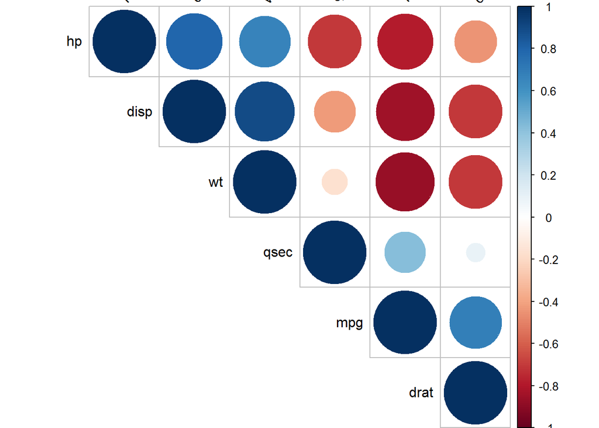

```r
corrplot(myCor, type = "upper", order = "hclust", tl.col = "black", tl.srt = 45)
```

It is also possible to combine correlogram with the significance test. Use the result myCor2 with rcorr() function.

Correlations with p-value > 0.01 are considered as insignificant.

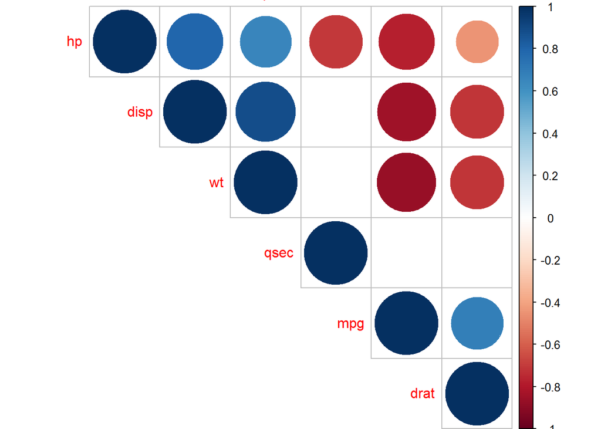

```r
# Insignificant correlation are crossed
corrplot(myCor2$r, type="upper", order="hclust", p.mat = myCor2$P, sig.level = 0.01, insig = "blank")
```

#### Scatter Plots

`chart.Correlation()` in `PerformanceAnalytics` can be used to display a chart of a correlation matrix.

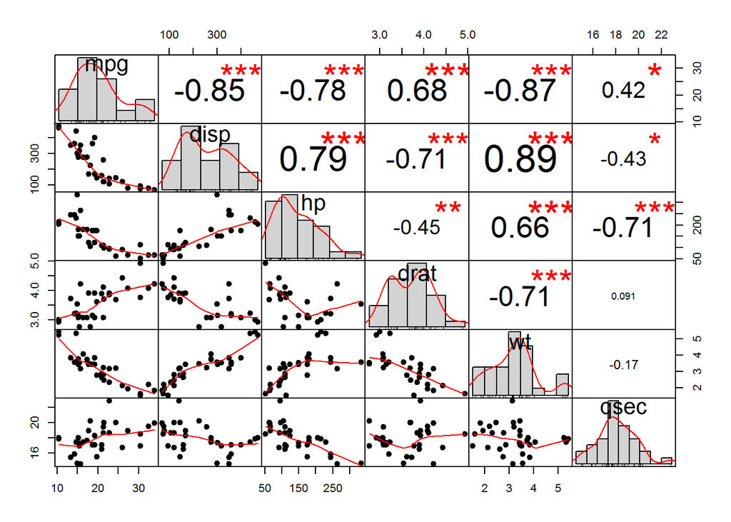

```r
myData <- mtcars[, c(1,3,4,5,6,7)]
chart.Correlation(myData, histogram=TRUE, pch=19)
```

- The distribution of each variable is shown on the diagonal.
- On the bottom of the diagonal : the bivariate scatter plots with a fitted line are displayed
- On the top of the diagonal : the value of the correlation plus the significance level as stars
- Each significance level is associated to a symbol : p-values(0, 0.001, 0.01, 0.05, 0.1, 1) <=> symbols(“***”, “**”, “*”, “.”, " “)

#### Heatmap

Using the heatmap function is pretty easy:

- x : the correlation matrix to be plotted
- col : color palettes
- symm : logical indicating if x should be treated symmetrically; can only be true when x is a square matrix.

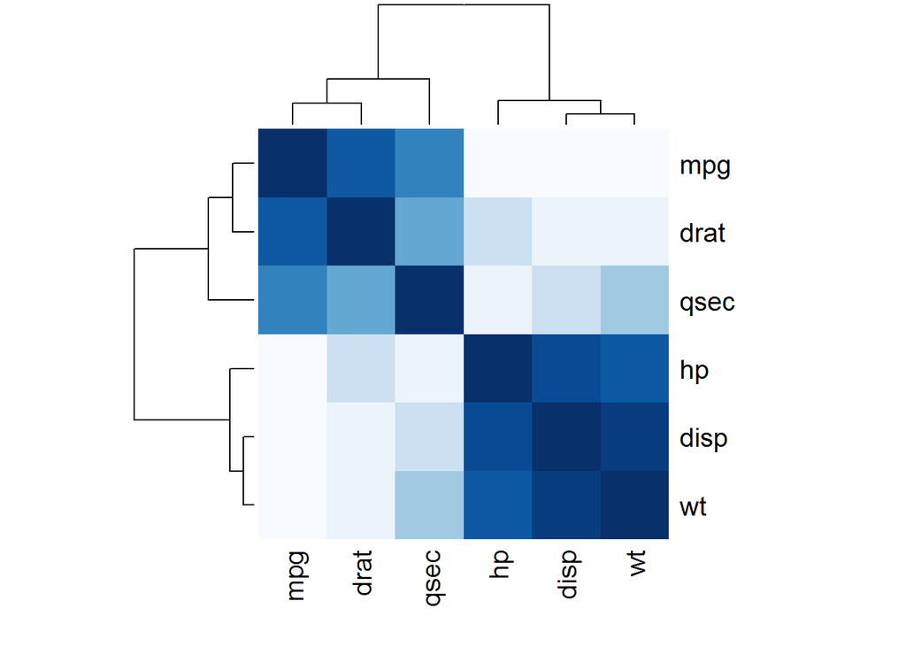

```r
col<- colorRampPalette(brewer.pal(9, "Blues"))(20)
heatmap(x = myCor, col = col, symm = TRUE)
```

## Linear Dependencies

The `caret` package has a function to find collinear numeric vectors in a data frame. It returns a list with the column numbers that are linear combinations of one another and the columns which can be removed to resolve this.

```r
df = data.frame( A = c( 1, 2, 3), B = c( 2, 4, 6), C = c( 3, 5, 1 ))
findLinearCombos(df)
```

```
## $linearCombos
## $linearCombos[[1]]
## [1] 2 1
##
##
## $remove
## [1] 2
```

If the data frame has multiple instances of linear combinations, use lapply over the list of linear combinations returned from findLinearCombos:

```r
df = data.frame( A = c( 1, 2, 3), B = c( 2, 4, 6), C = c( 3, 5, 1 ), D = c( 6, 10, 2))
myCollinear = findLinearCombos(df)
myCollinear
```

```
## $linearCombos
## $linearCombos[[1]]
## [1] 2 1
##
## $linearCombos[[2]]
## [1] 4 3
##
##
## $remove
## [1] 2 4
```

```r
#Get the column names
lapply(myCollinear$linearCombos, function(x) colnames(df)[x])
```

```
## [[1]]
## [1] "B" "A"
##
## [[2]]
## [1] "D" "C"
```

Armed with this information, it is simple to remove the collinear variables.

```r
df = data.frame( A = c( 1, 2, 3), B = c( 2, 4, 6), C = c( 3, 5, 1 ), D = c( 6, 10, 2))
df
```

```
##   A B C  D
## 1 1 2 3  6
## 2 2 4 5 10
## 3 3 6 1  2
```

```r
myCollinear = findLinearCombos(df)
myCollinear
```

```
## $linearCombos
## $linearCombos[[1]]
## [1] 2 1
##
## $linearCombos[[2]]
## [1] 4 3
##
##
## $remove
## [1] 2 4
```

```r
df[-myCollinear$remove]
```

```
##   A C
## 1 1 3
## 2 2 5
## 3 3 1
```

This is so simple to do, do not forget to do it!!

## PreProcessing

The caret package in R provides a number of useful data transforms.

These transforms can be used in two ways.

- Standalone: Transforms can be modeled from training data and applied to multiple data sets. The model of the transform is prepared using the preProcess() function and applied to a data set using the predict() function.
- Training: Transforms can prepared and applied automatically during model evaluation. Transforms applied during training are prepared using the preProcess() and passed to the train() function via the preProcess argument.

### Scale

The scale transform calculates the standard deviation for an attribute and divides each value by that standard deviation.

```r
data(iris)
summary(iris[,1:4])
```

```
##   Sepal.Length    Sepal.Width     Petal.Length    Petal.Width
##  Min.   :4.300   Min.   :2.000   Min.   :1.000   Min.   :0.100
##  1st Qu.:5.100   1st Qu.:2.800   1st Qu.:1.600   1st Qu.:0.300
##  Median :5.800   Median :3.000   Median :4.350   Median :1.300
##  Mean   :5.843   Mean   :3.057   Mean   :3.758   Mean   :1.199
##  3rd Qu.:6.400   3rd Qu.:3.300   3rd Qu.:5.100   3rd Qu.:1.800
##  Max.   :7.900   Max.   :4.400   Max.   :6.900   Max.   :2.500
```

```r
# calculate the pre-process parameters from the dataset
preprocessParams <- preProcess(iris[,1:4], method=c("scale"))
print(preprocessParams)
```

```
## Created from 150 samples and 4 variables
##
## Pre-processing:
##   - ignored (0)
##   - scaled (4)
```

```r
# transform the dataset using the parameters
transformed <- predict(preprocessParams, iris[,1:4])
summary(transformed)
```

```
##   Sepal.Length    Sepal.Width      Petal.Length     Petal.Width
##  Min.   :5.193   Min.   : 4.589   Min.   :0.5665   Min.   :0.1312
##  1st Qu.:6.159   1st Qu.: 6.424   1st Qu.:0.9064   1st Qu.:0.3936
##  Median :7.004   Median : 6.883   Median :2.4642   Median :1.7055
##  Mean   :7.057   Mean   : 7.014   Mean   :2.1288   Mean   :1.5734
##  3rd Qu.:7.729   3rd Qu.: 7.571   3rd Qu.:2.8890   3rd Qu.:2.3615
##  Max.   :9.540   Max.   :10.095   Max.   :3.9087   Max.   :3.2798
```

### Center

The center transform calculates the mean for an attribute and subtracts it from each value.

```r
# calculate the pre-process parameters from the dataset
preprocessParams <- preProcess(iris[,1:4], method=c("center"))
print(preprocessParams)
```

```
## Created from 150 samples and 4 variables
##
## Pre-processing:
##   - centered (4)
##   - ignored (0)
```

```r
# transform the dataset using the parameters
transformed <- predict(preprocessParams, iris[,1:4])
summary(transformed)
```

```
##   Sepal.Length       Sepal.Width        Petal.Length     Petal.Width
##  Min.   :-1.54333   Min.   :-1.05733   Min.   :-2.758   Min.   :-1.0993
##  1st Qu.:-0.74333   1st Qu.:-0.25733   1st Qu.:-2.158   1st Qu.:-0.8993
##  Median :-0.04333   Median :-0.05733   Median : 0.592   Median : 0.1007
##  Mean   : 0.00000   Mean   : 0.00000   Mean   : 0.000   Mean   : 0.0000
##  3rd Qu.: 0.55667   3rd Qu.: 0.24267   3rd Qu.: 1.342   3rd Qu.: 0.6007
##  Max.   : 2.05667   Max.   : 1.34267   Max.   : 3.142   Max.   : 1.3007
```

### Standardize

Combining the scale and center transforms will standardize your data. Attributes will have a mean value of 0 and a standard deviation of 1.

```r
# calculate the pre-process parameters from the dataset
preprocessParams <- preProcess(iris[,1:4], method=c("center", "scale"))
print(preprocessParams)
```

```
## Created from 150 samples and 4 variables
##
## Pre-processing:
##   - centered (4)
##   - ignored (0)
##   - scaled (4)
```

```r
# transform the dataset using the parameters
transformed <- predict(preprocessParams, iris[,1:4])
summary(transformed)
```

```
##   Sepal.Length       Sepal.Width       Petal.Length      Petal.Width
##  Min.   :-1.86378   Min.   :-2.4258   Min.   :-1.5623   Min.   :-1.4422
##  1st Qu.:-0.89767   1st Qu.:-0.5904   1st Qu.:-1.2225   1st Qu.:-1.1799
##  Median :-0.05233   Median :-0.1315   Median : 0.3354   Median : 0.1321
##  Mean   : 0.00000   Mean   : 0.0000   Mean   : 0.0000   Mean   : 0.0000
##  3rd Qu.: 0.67225   3rd Qu.: 0.5567   3rd Qu.: 0.7602   3rd Qu.: 0.7880
##  Max.   : 2.48370   Max.   : 3.0805   Max.   : 1.7799   Max.   : 1.7064
```

### Normalize

Data values can be scaled into the range of [0, 1] which is called normalization.

```r
# calculate the pre-process parameters from the dataset
preprocessParams <- preProcess(iris[,1:4], method=c("range"))
print(preprocessParams)
```

```
## Created from 150 samples and 4 variables
##
## Pre-processing:
##   - ignored (0)
##   - re-scaling to [0, 1] (4)
```

```r
# transform the dataset using the parameters
transformed <- predict(preprocessParams, iris[,1:4])
summary(transformed)
```

```
##   Sepal.Length     Sepal.Width      Petal.Length     Petal.Width
##  Min.   :0.0000   Min.   :0.0000   Min.   :0.0000   Min.   :0.00000
##  1st Qu.:0.2222   1st Qu.:0.3333   1st Qu.:0.1017   1st Qu.:0.08333
##  Median :0.4167   Median :0.4167   Median :0.5678   Median :0.50000
##  Mean   :0.4287   Mean   :0.4406   Mean   :0.4675   Mean   :0.45806
##  3rd Qu.:0.5833   3rd Qu.:0.5417   3rd Qu.:0.6949   3rd Qu.:0.70833
##  Max.   :1.0000   Max.   :1.0000   Max.   :1.0000   Max.   :1.00000
```

### Box-Cox Transform

When an attribute has a Gaussian-like distribution but is shifted, this is called a skew. The distribution of an attribute can be shifted to reduce the skew and make it more Gaussian. The BoxCox transform can perform this operation (assumes all values are positive).

Applied the transform to only two attributes that appear to have a skew.

```r
data(PimaIndiansDiabetes)
summary(PimaIndiansDiabetes[,7:8])
```

```
##     pedigree           age
##  Min.   :0.0780   Min.   :21.00
##  1st Qu.:0.2437   1st Qu.:24.00
##  Median :0.3725   Median :29.00
##  Mean   :0.4719   Mean   :33.24
##  3rd Qu.:0.6262   3rd Qu.:41.00
##  Max.   :2.4200   Max.   :81.00
```

```r
# calculate the pre-process parameters from the dataset
preprocessParams <- preProcess(PimaIndiansDiabetes[,7:8], method=c("BoxCox"))
print(preprocessParams)
```

```
## Created from 768 samples and 2 variables
##
## Pre-processing:
##   - Box-Cox transformation (2)
##   - ignored (0)
##
## Lambda estimates for Box-Cox transformation:
## -0.1, -1.1
```

```r
# transform the dataset using the parameters
transformed <- predict(preprocessParams, PimaIndiansDiabetes[,7:8])
summary(transformed)
```

```
##     pedigree            age
##  Min.   :-2.5510   Min.   :0.8772
##  1st Qu.:-1.4116   1st Qu.:0.8815
##  Median :-0.9875   Median :0.8867
##  Mean   :-0.9599   Mean   :0.8874
##  3rd Qu.:-0.4680   3rd Qu.:0.8938
##  Max.   : 0.8838   Max.   :0.9019
```

### Yeo-Johnson Transform

Another power-transform like the Box-Cox transform but it supports raw values that are equal to zero and negative.

```r
# load libraries
# calculate the pre-process parameters from the dataset
preprocessParams <- preProcess(PimaIndiansDiabetes[,7:8], method=c("YeoJohnson"))
print(preprocessParams)
```

```
## Created from 768 samples and 2 variables
##
## Pre-processing:
##   - ignored (0)
##   - Yeo-Johnson transformation (2)
##
## Lambda estimates for Yeo-Johnson transformation:
## -2.25, -1.15
```

```r
# transform the dataset using the parameters
transformed <- predict(preprocessParams, PimaIndiansDiabetes[,7:8])
summary(transformed)
```

```
##     pedigree           age
##  Min.   :0.0691   Min.   :0.8450
##  1st Qu.:0.1724   1st Qu.:0.8484
##  Median :0.2265   Median :0.8524
##  Mean   :0.2317   Mean   :0.8530
##  3rd Qu.:0.2956   3rd Qu.:0.8580
##  Max.   :0.4164   Max.   :0.8644
```

### Principal Component Analysis

Transform the data to the principal components. The transform keeps components above the variance threshold (default=0.95) or the number of components can be specified (pcaComp). The result is attributes that are uncorrelated, useful for algorithms like linear and generalized linear regression.

```r
# calculate the pre-process parameters from the dataset
preprocessParams <- preProcess(iris, method=c("center", "scale", "pca"))
print(preprocessParams)
```

```
## Created from 150 samples and 5 variables
##
## Pre-processing:
##   - centered (4)
##   - ignored (1)
##   - principal component signal extraction (4)
##   - scaled (4)
##
## PCA needed 2 components to capture 95 percent of the variance
```

```r
# transform the dataset using the parameters
transformed <- predict(preprocessParams, iris)
summary(transformed)
```

```
##        Species        PC1               PC2
##  setosa    :50   Min.   :-2.7651   Min.   :-2.67732
##  versicolor:50   1st Qu.:-2.0957   1st Qu.:-0.59205
##  virginica :50   Median : 0.4169   Median :-0.01744
##                  Mean   : 0.0000   Mean   : 0.00000
##                  3rd Qu.: 1.3385   3rd Qu.: 0.59649
##                  Max.   : 3.2996   Max.   : 2.64521
```

### Independent Component Analysis

Transform the data to the independent components. Unlike PCA, ICA retains those components that are independent. You must specify the number of desired independent components with the n.comp argument. Useful for algorithms such as naive bayes.

```r
# calculate the pre-process parameters from the dataset
preprocessParams <- preProcess(PimaIndiansDiabetes[,1:8], method=c("center", "scale", "ica"), n.comp=5)
print(preprocessParams)
```

```
## Created from 768 samples and 8 variables
##
## Pre-processing:
##   - centered (8)
##   - independent component signal extraction (8)
##   - ignored (0)
##   - scaled (8)
##
## ICA used 5 components
```

```r
# transform the dataset using the parameters
transformed <- predict(preprocessParams, PimaIndiansDiabetes[,1:8])
summary(transformed)
```

```
##       ICA1               ICA2              ICA3               ICA4
##  Min.   :-4.89616   Min.   :-6.0205   Min.   :-2.38013   Min.   :-1.4151
##  1st Qu.:-0.48398   1st Qu.:-0.4286   1st Qu.:-0.73800   1st Qu.:-0.8412
##  Median : 0.02406   Median : 0.2596   Median : 0.07315   Median :-0.2781
##  Mean   : 0.00000   Mean   : 0.0000   Mean   : 0.00000   Mean   : 0.0000
##  3rd Qu.: 0.59492   3rd Qu.: 0.6824   3rd Qu.: 0.72173   3rd Qu.: 0.7706
##  Max.   : 4.17227   Max.   : 1.5755   Max.   : 2.93716   Max.   : 3.0692
##       ICA5
##  Min.   :-5.5401
##  1st Qu.:-0.4688
##  Median : 0.1391
##  Mean   : 0.0000
##  3rd Qu.: 0.6492
##  Max.   : 3.2185
```

> Note: I often ger PCA and ICA confused. I always seem to have to look them up to make sure I am using the right tool for feature extraction. If you suffer from this too, tlake a look at this [link](http://blog.haunschmid.name/dimensionality-reduction-1-understanding-pca-and-ica-using-r/). It helps me all the time.

### PreProcess Summary

Below are some tips for getting the most out of data transforms.

- **Use Them**: You are a step ahead if you are thinking about and using data transforms to prepare your data. It is an easy step to forget or skip over and often has a huge impact on the accuracy of your final models.
- **Use a Variety**: Try a number of different data transforms on your data with a suite of different machine learning algorithms.
- **Review a Summary**: Summarize your data before and after a transform to understand the effect it had.
- **Visualize Data**: Visualize the distribution of your data before and after to get a spatial intuition for the effect of the transform.

## Transforming Predictors

In some cases, there is a need to use principal component analysis (PCA) to transform the data to a smaller sub–space where the new variable are uncorrelated with one another. The preProcess class can apply this transformation by including “pca” in the method argument. Doing this will also force scaling of the predictors. Note that when PCA is requested, predict.preProcess changes the column names to PC1, PC2 and so on.